# ML Project

Ted W Thetford

Saturday, March 21, 2015

### Introduction

Using devices such as Jawbone Up, Nike FuelBand, and Fitbit it is now possible to collect a large amount of personal activity data relatively inexpensively. These type of devices are part of the quantified self movement - a group of enthusiasts who take measurements about themselves regularly to improve their health. One thing that people regularly do is quantify how much of a particular activity they do, but they rarely quantify how well they do it. In this project, I will use data from accelerometers on the belt, forearm, arm, and dumbell of six participants.

The participants were asked to perform one set of 10 repetitions of the Unilateral Dumbbell Biceps Curl in five different fashions: exactly according to the specification (Class A), throwing the elbows to the front (Class B), lifting the dumbbell only halfway (Class C), lowering the dumbbell only halfway (Class D) and throwing the hips to the front (Class E). Class A corresponds to the specified execution of the exercise, while the other four classes correspond to common mistakes.

### Data Cleaning

The data was previously downloaded. I read the data and found that both datasets had 160 columns/variables and the training set had 19,622 rows where the testing set had 20 rows. Since many columns had missing data (null, blank, or NA), I normalized the missing values to be NA while reading the files for easier data cleaning.

```r
testing_data <- read.csv("pml-testing.csv",na.strings=c(""," ","NA"))
dim(testing_data)
```

```
## [1]  20 160
```

```r
#
training_data <- read.csv("pml-training.csv",na.strings=c(""," ","NA"))
dim(training_data)
```

```
## [1] 19622   160
```

As it is important when building a model to have only data in your dataframe that corresponds to the outcome (variable=casse). I removed the columns that had data but had no correlation to calculating the outcome variable.

```r
testing_data <- testing_data[,-c(1,3:7)]
training_data <- training_data[,-c(1,3:7)]
```

I ran a random forest model against this data and was only able to gain an accuracy of 79.1%. Even though many columns have no data or NA, they must be impacting the accuracy of the model. Because of this possibility, I identified and only kept the columns that have data. Now the testing and training dataframes only have 54 columns each.

```r
test_data_clean <- testing_data[, colSums(is.na(testing_data)) == 0]
dim(test_data_clean)
```

```
## [1] 20 54
```

```r
#
train_data_clean <- training_data[, colSums(is.na(training_data)) == 0]
dim(train_data_clean)
```

```
## [1] 19622    54
```

### Prepare and Build Model

I split the remaining training dataframe into a training set (70%) and a testing or valdation dataset (30%).

```r
set.seed(888)
inTrain <- createDataPartition(train_data_clean$classe, p=0.70, list=FALSE)
train_data <- train_data_clean[inTrain, ]
test_data <- train_data_clean[-inTrain, ]
```

I decided to use the Random Forests algorithm to develop the predictive model because it is one of the best among classification algorithms and is able to to classify large amounts of data with accuracy and is relatively efficient in doing so.

```r
random_forest_mod <- train(classe ~ ., data=train_data, method="rf",ntree=50,
          trControl=trainControl(method = "cv",number = 10,allowParallel=TRUE))
random_forest_mod$finalModel
```

```
##
## Call:
##  randomForest(x = x, y = y, ntree = 50, mtry = param$mtry)
##                Type of random forest: classification
##                      Number of trees: 50
## No. of variables tried at each split: 29
##
##         OOB estimate of  error rate: 0.86%
## Confusion matrix:
##      A    B    C    D    E class.error
## A 3896    8    1    1    0 0.002560164
## B   18 2625   15    0    0 0.012415350
## C    1   18 2362   13    2 0.014190317
## D    0    2   25 2224    1 0.012433393
## E    1    3    3    6 2512 0.005148515
```

```r
#
random_forest_pred <- predict(random_forest_mod, test_data)
confusionMatrix(test_data$classe, random_forest_pred)
```

```
## Confusion Matrix and Statistics
##
##           Reference
## Prediction    A    B    C    D    E
##          A 1674    0    0    0    0
##          B   12 1123    4    0    0
##          C    0    2 1024    0    0
##          D    0    0   10  953    1
##          E    0    1    0    4 1077
##
## Overall Statistics
##
##                Accuracy : 0.9942
##                  95% CI : (0.9919, 0.996)
##     No Information Rate : 0.2865
##     P-Value [Acc > NIR] : < 2.2e-16
##
##                   Kappa : 0.9927
##  Mcnemar's Test P-Value : NA
##
## Statistics by Class:
##
##                      Class: A Class: B Class: C Class: D Class: E
## Sensitivity            0.9929   0.9973   0.9865   0.9958   0.9991
## Specificity            1.0000   0.9966   0.9996   0.9978   0.9990
## Pos Pred Value         1.0000   0.9860   0.9981   0.9886   0.9954
## Neg Pred Value         0.9972   0.9994   0.9971   0.9992   0.9998
## Prevalence             0.2865   0.1913   0.1764   0.1626   0.1832
## Detection Rate         0.2845   0.1908   0.1740   0.1619   0.1830
## Detection Prevalence   0.2845   0.1935   0.1743   0.1638   0.1839
## Balanced Accuracy      0.9964   0.9970   0.9930   0.9968   0.9990
```

### Results

In testing different random forest model options, I increased the folds and was able to produce small improvements in the accuracy. As the improvements were small, I settled on 10 folds (gained +0.3% going from 5 to 10 folds). Because the random forest model takes so long to execute and that the number of trees default is 500, I started with 250 trees and I kept reducing the number of trees down to gain performance. The accuracy loss from 250 trees to 50 was quite small (less than (0.09%). The model with 10 folds and 50 trees provided an accuracy of 99.42% with a significant p-value of 2.2e-16 and a very small OOB error rate of 0.86%.

```r
test_forest_mod <- predict(random_forest_mod, test_data_clean)
test_forest_mod
```

```
##  [1] B A B A A E D B A A B C B A E E A B B B
## Levels: A B C D E
```

### Appendix:

Correlation Matrix Visualization: I used the corrgram function to provide a what I feel is an easier to interpret plot of the correlation between variables. On the left of the diagnol the correlations are strongest when the result is dark blue and weakest when it is dark red and varies in the range between. To the right of the diagnol the pies that have the majority filled in with blue are the strongest correlations and the weakest correlations are the full pies of red with the correlation varying between these two extremes.

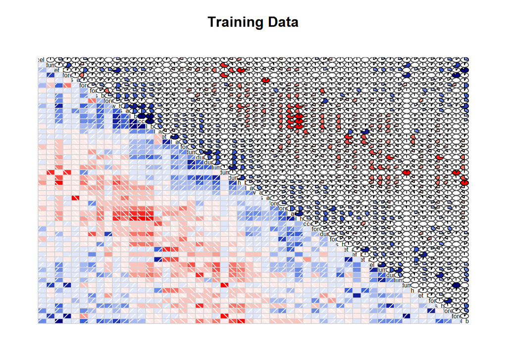

```r
corrgram(train_data, order=TRUE, lower.panel=panel.shade,
         upper.panel=panel.pie, text.panel=panel.txt,
         main="Training Data")
```

Simplified Decision Tree Visualizaiton

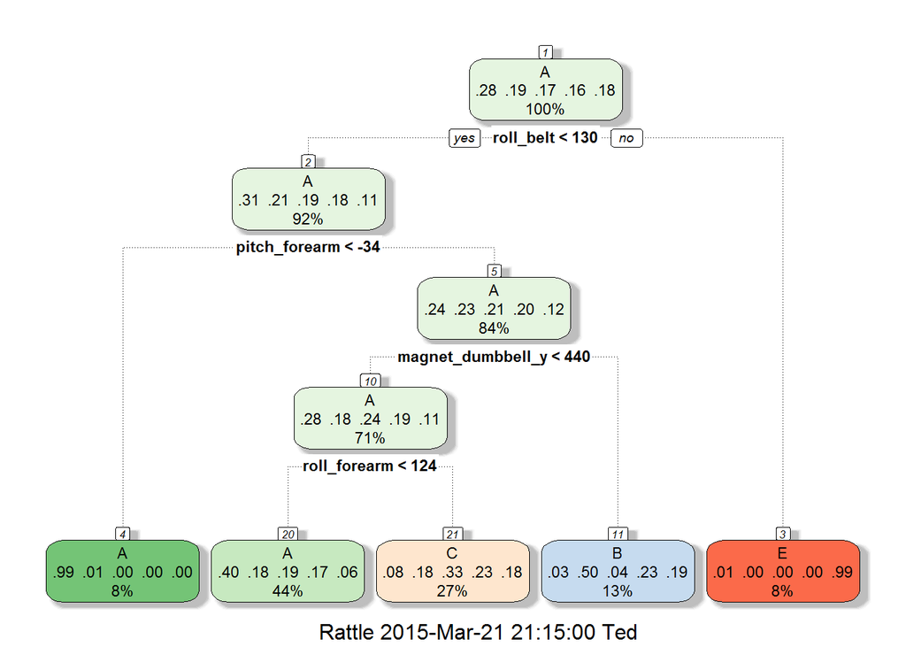

```r
fan_dec_tree_viz <- train(classe ~ ., data=train_data, method="rpart")
fancyRpartPlot(fan_dec_tree_viz$finalModel)
```

Detailed Decision Tree Visualization

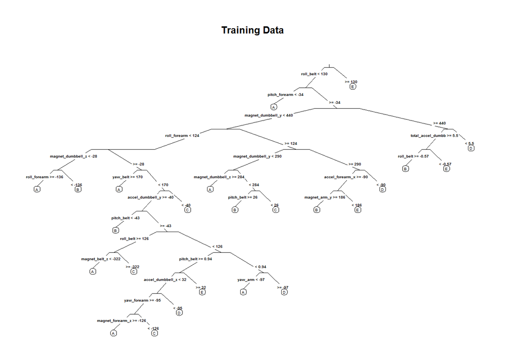

```r
dec_tree_viz <- rpart(classe ~ ., data=train_data, method="class")
prp(dec_tree_viz,type=3,tweak=1.2,main="Training Data")
```